# PRECIS-2 Scores in PragMeta: Human Consensus vs LMM (GPT 3.5)

### Score comparisons of 54 publications

| Ref. | Author & Year | weighted κ | agreement | pooled weighted κ | pooled agreement |
| --- | --- | --- | --- | --- | --- |
| 648 | CORONIS Collaborative Group (2013) | 0.159340659340659 | 0.444444444444444 | 0.234042553191489 | 0.555555555555556 |
| 650 | van Dijk-de Vries. A, (2015) | -0.0909090909090911 | 0.333333333333333 | 0 | 0.666666666666667 |
| 651 | Price. D, (2011) | -0.421052631578947 | 0.222222222222222 | -0.105263157894737 | 0.555555555555556 |
| 655 | Galdiz, J. B. (2020) | 0 | 0.333333333333333 | 0.117647058823529 | 0.444444444444444 |
| 657 | Arntzen E. (2019) | 0.25 | 0.333333333333333 | -0.125 | 0.777777777777778 |
| 663 | Callesen J. (2020) | -0.190082644628099 | 0.222222222222222 | -0.161290322580645 | 0.555555555555556 |
| 664 | Carter A. (2014) | -0.0551724137931033 | 0.111111111111111 | 0.076923076923077 | 0.555555555555556 |
| 665 | Cooper C. (2011) | -0.227272727272727 | 0.333333333333333 | 0 | 0.666666666666667 |
| 666 | Cutter G. (2019) | 0.292134831460674 | 0.444444444444444 | 0.217391304347826 | 0.555555555555556 |
| 668 | Dodd K. J. (2011) | -0.3125 | 0.222222222222222 | -0.0384615384615385 | 0.666666666666667 |

[output cut: 44 more lines]

### Score heatmaps (unpooled / pooled)

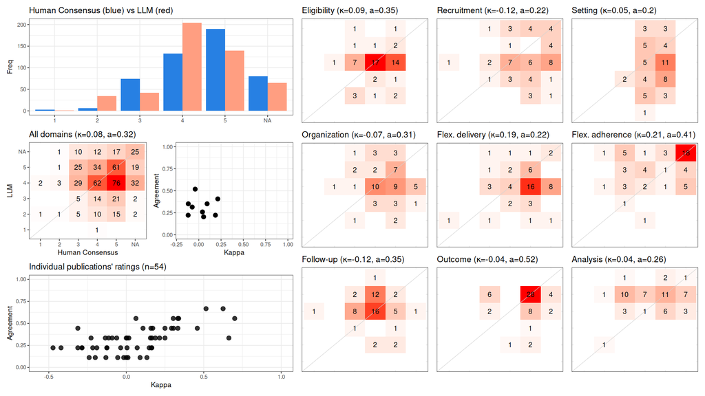

### Individual results

#### 648. CORONIS Collaborative Group (2013): *Caesarean section surgical techniques (CORONIS): a fractional, factorial, unmasked, randomised controlled trial*

PRECIS-2

|  | D1 | D2 | D3 | D4 | D5 | D6 | D7 | D8 | D9 |
| --- | --- | --- | --- | --- | --- | --- | --- | --- | --- |
| Human Consensus | 4 | NA | 5 | 5 | 3 | NA | 5 | 3 | 3 |
| LLM | 4 | 5 | 4 | 5 | 5 | NA | 5 | 5 | 5 |

LLM response

*Minor score formatting issues fixed during extraction: ‘not-applicable-without-score’*

*8 quote(s) from publication full text (mean similarity 100%)*

```
Eligibility:
- "Pregnant women were eligible if they were to undergo their first or second caesarean section through a planned transverse abdominal incision." [1]
- Score: [4] The eligibility criteria are somewhat pragmatic as they include pregnant women who are undergoing their first or second caesarean section, which is similar to usual care. However, the criteria exclude women who have a clear indication for a particular surgical technique or material, whi…

Recruitment:
- "The trial was discussed with all eligible women and their partners and relatives as appropriate. If the woman agreed to participate, she signed a formal consent form or used the method of recording consent permitted in that setting." [2]
- Score: [5] The recruitment process seems very pragmatic as it involves discussing the trial with eligible women during their care and obtaining informed consent, which is similar to usual care.

Setting:
- "CORONIS was undertaken at 19 sites in Argentina, Chile, Ghana, India, Kenya, Pakistan, and Sudan." [2]
- Score: [4] The trial was conducted at multiple sites in different countries, which is somewhat pragmatic. However, the trial was not conducted in a wide range of settings and was limited to specific countries, which is more explanatory.

Organisation:
- "All investigators, surgeons, and participants were unmasked to treatment allocation." [2]
- Score: [5] The trial was conducted in an unmasked manner, which is similar to usual care.

Flexibility (delivery):
- "All non-allocated surgical elements and all other aspects of the caesarean section procedure were undertaken at the discretion of the surgeon." [2]
- Score: [5] The surgeons had discretion in performing the non-allocated surgical elements, which is similar to usual care.

Flexibility (adherence):
- Not applicable. Score: [NA] The full text does not provide information on adherence to the intervention.

Follow-up:
- "Data were collected at trial entry, immediately after surgery, at hospital discharge, and at about 6 weeks after delivery." [2]
- Score: [5] The follow-up schedule includes data collection at multiple time points, including the 6-week follow-up visit, which is similar to usual care.

Primary outcome:
- "There were no statistically significant differences within any of the intervention pairs for the primary outcome." [2]
- Score: [5] The trial found no statistically significant differences in the primary outcome, suggesting that the trial's primary outcome is relevant to participants.

Primary analysis:
- "Women were analysed in the groups into which they were allocated." [2]
- Score: [5] The primary analysis included all women in the groups to which they were allocated, which is similar to an intention-to-treat analysis and is pragmatic.

Overall, the trial seems to have a pragmatic design, with some domains leaning more towards explanatory. The eligibility criteria, recruitment process, flexibility in delivery, and primary analysis are all pragmatic. However, the setting and organisation of the trial are somewhat explanatory. The tr…
```

#### 650. [van Dijk-de Vries. A, (2015): *Lessons learnt from a cluster-randomised trial evaluating the effectiveness of Self-Management Support (SMS) delivered by practice nurses in routine diabetes care*](https://doi.org/10.1136/bmjopen-2014-007014)

PRECIS-2

|  | D1 | D2 | D3 | D4 | D5 | D6 | D7 | D8 | D9 |
| --- | --- | --- | --- | --- | --- | --- | --- | --- | --- |
| Human Consensus | 3 | 4 | 5 | 4 | 5 | NA | 4 | 5 | 3 |
| LLM | 4 | 4 | 4 | 4 | 4 | 4 | 5 | 5 | 5 |

LLM response

*12 quote(s) from publication full text (mean similarity 98.3%)*

```
Eligibility:
- "Patients with type 2 diabetes (n=264) selected by a self-administered questionnaire aimed at measuring emotional distress and diabetes-related reduced daily functioning." [1]
- "The eligibility criteria changed from having a mild to moderate depression towards suffering from both emotional distress and interference in their daily functioning due to the burden of diabetes." [1]
- Score: [4] The eligibility criteria for this trial are somewhat pragmatic, as they focus on patients with emotional distress and reduced daily functioning related to diabetes. However, the criteria are still somewhat explanatory as they exclude patients with mild to moderate depression.

Recruitment:
- "All the family practices of one regional organisation of GPs (a so-called ‘care group’) in the South of the Netherlands were eligible to participate in the study." [2]
- "From the 3822 patients with diabetes who were sent a screening questionnaire, 264 patients gave informed consent to participate in the trial." [2]
- Score: [4] The recruitment methods used in this trial are somewhat pragmatic, as they involve all eligible family practices and a large number of patients. However, the trial did not use targeted invitation letters or other methods to actively recruit participants, which would have made it more pr…

Setting:
- "A regional care group in the Netherlands consisting of 77 family practices." [2]
- Score: [4] The setting of this trial is somewhat pragmatic, as it involves a regional care group with multiple family practices. However, it is not clear if the trial was conducted in other types of settings, such as academic or specialized trial centers.

Organisation:
- "PNs in the intervention arm were trained in SMS, whereas PNs in the control arm provided usual diabetes care, conforming to the Dutch guidelines." [2]
- "Financial reimbursement for the extra time spent on SMS was added to the bundled payment arrangement for diabetes care." [2]
- Score: [4] The organization of care delivery in this trial is somewhat pragmatic, as it involves training practice nurses in SMS and providing financial reimbursement for the extra time spent on SMS. However, it is not clear if there were any other changes to the organization of care delivery in t…

Flexibility (delivery):
- "PNs supported patients in the processes of defining problems and finding solutions themselves, by applying problem-solving and reattribution techniques." [2]
- Score: [4] The flexibility in how the intervention is delivered in this trial is somewhat pragmatic, as it involves supporting patients in problem-solving and reattribution techniques. However, it is not clear if there were any strict protocols or measures to improve compliance.

Flexibility (adherence):
- "Patients who experienced problems of daily functioning and emotional health problems were offered consultations for SMS." [2]
- Score: [4] The flexibility in how participants must adhere to the intervention in this trial is somewhat pragmatic, as it involves offering consultations for SMS to patients who experience problems. However, it is not clear if there were any strict protocols or measures to improve adherence.

Follow-up:
- "Outcomes were measured at baseline and at 4-month and 12-month follow-ups." [2]
- Score: [5] The intensity of measurement and follow-up in this trial is very pragmatic, as it involves measuring outcomes at multiple time points similar to usual care.

Primary outcome:
- "The primary outcome measure was a dichotomised score on a Visual Analogue Scale that measured the perceived effect of diabetes on daily functioning." [2]
- Score: [5] The primary outcome measure in this trial is very pragmatic, as it directly measures the perceived effect of diabetes on daily functioning.

Primary analysis:
- "Analyses were performed on an intention-to-treat basis." [2]
- Score: [5] The primary analysis in this trial is very pragmatic, as it includes all available data on an intention-to-treat basis.

Overall, this trial has a somewhat pragmatic design, with scores ranging from 4 to 5 in most domains. However, there is some lack of information in certain domains, such as flexibility in delivery and adherence, which prevents a complete assessment.
```

#### 651. [Price. D, (2011): *Leukotriene antagonists as first-line or add-on asthma-controller therapy*](https://doi.org/10.1056/NEJMoa1010846)

PRECIS-2

|  | D1 | D2 | D3 | D4 | D5 | D6 | D7 | D8 | D9 |
| --- | --- | --- | --- | --- | --- | --- | --- | --- | --- |
| Human Consensus | 5 | 5 | 5 | NA | 4 | 4 | 4 | 5 | 4 |
| LLM | 3 | 4 | 2 | 4 | 4 | 5 | 5 | 3 | 4 |

LLM response

*18 quote(s) from publication full text (mean similarity 100%)*

```
Eligibility:
1. "In the case of asthma, for example, the eligibility criteria in most such trials exclude an estimated 95% of patients with a current diagnosis of asthma, including smokers and those who have “insufficient” bronchodilator reversibility or impaired pulmonary function." [Explanatory]
2. "We designed these two pragmatic trials to maximize external validity (applicability or generalizability), with the goal of studying a heterogeneous real-world population." [Pragmatic]
Score: [3]

Recruitment:
1. "Patients were responsible for obtaining their own medications, as would occur in real life." [Pragmatic]
2. "We considered but rejected the addition of a placebo group when designing the study, since we believe it would have been unethical to assign patients to placebo for 2 years." [Pragmatic]
Score: [4]

Setting:
1. "Both trials were conducted in accordance with the protocol." [Explanatory]
2. "The study was powered for equivalence in the MiniAQLQ score, with the equivalence boundary set at a 95% CI of less than 0.3 for the MiniAQLQ score (i.e., equivalence was declared if the 95% CI was wholly included between –0.3 and 0.3)." [Explanatory]
Score: [2]

Organisation:
1. "The primary funder and sponsor (National Coordinating Centre for Health Technology Assessment U.K.) provided input with regard to the study design through its commissioning and monitoring brief but played no role in data collection, analysis, or interpretation; the writing of the article; or the…
2. "Practice staffs were asked to provide each patient with a written individualized asthma-action plan." [Pragmatic]
Score: [4]

Flexibility (delivery):
1. "Choices of individual drugs and devices were made according to normal clinical practice and British asthma guidelines." [Pragmatic]
2. "The protocol discouraged substantial treatment changes between randomization and the 2-month visit." [Pragmatic]
Score: [4]

Flexibility (adherence):
1. "Adherence to an LTRA was better than it was to the other drugs in both trials." [Pragmatic]
2. "Although such poor and differential adherence potentially reduces assay sensitivity (particularly when coupled with treatment crossover), thus biasing results toward equivalence, both poor and differential adherence rates are realities of real-world prescribing and thus part of the treatment eff…
Score: [5]

Follow-up:
1. "Data collection and statistical analyses were performed by study personnel who were unaware of the treatment assignments; questionnaire-based data were collected under blinded conditions, and routine practice data (including a history of exacerbations) were extracted with the use of dedicated so…
2. "Data for asthma-related quality of life and asthma control were available over a period of 21 months for 95% and 96% of the patients in the first-line controller and add-on therapy trials, respectively, which are completion rates higher than those in most long-term asthma-therapy trials." [Pragm…
Score: [5]

Primary outcome:
1. "Mean improvements over a period of 2 years in both the first-line controller and the add-on therapy trials were substantially greater than the MID for questionnaire scores measuring asthma-related quality of life and asthma control." [Pragmatic]
2. "For patients receiving an LTRA or an inhaled glucocorticoid as first-line controller therapy, MiniAQLQ scores were equivalent at 2 months, but at 2 years, these scores did not meet our prespecified criterion for equivalence, since the lower boundary of the 95% CI was –0.35." [Explanatory]
Score: [3]

Primary analysis:
1. "The primary effectiveness analysis was an intention-to-treat analysis of the MiniAQLQ score at 2 months (the primary time point) and at 2 years." [Pragmatic]
2. "Multiple imputation was used where data were missing." [Pragmatic]
Score: [4]
```

#### 655. [Galdiz, J. B. (2020): *Telerehabilitation Programme as a Maintenance Strategy for COPD Patients: A 12-Month Randomized Clinical Trial*](https://doi.org/10.1016/j.arbres.2020.03.034)

PRECIS-2

|  | D1 | D2 | D3 | D4 | D5 | D6 | D7 | D8 | D9 |
| --- | --- | --- | --- | --- | --- | --- | --- | --- | --- |
| Human Consensus | 3 | NA | 5 | 4 | 5 | 3 | 4 | 3 | 3 |
| LLM | 4 | NA | 3 | 4 | 4 | NA | 4 | 5 | 5 |

LLM response

*Minor score formatting issues fixed during extraction: ‘squared-brackets-around-score’, ‘multiple-scores-per-domain-if-incongruent-na’*

*9 quote(s) from publication full text (mean similarity 100%)*

```
Eligibility:
1. "Patient selection criteria were having a diagnosis of moderate-to-severe COPD (a Body mass index, Airflow obstruction, dyspnoea and Exercise capacity [BODE] index score of 3–7) according to international guidelines and having been clinically stable for the previous 4 weeks." Score: [4] The eligi…

Recruitment:
1. "Recruited patients (recruitment visit, −1) attended an initial 8-week outpatient-based PR programme conducted in each hospital rehabilitation department." Score: [4] The recruitment process involved patients attending an outpatient-based PR program, which is similar to usual care. However, the s…
2. "All patients gave written informed consent." Score: [5] The use of written informed consent suggests that the recruitment process followed standard ethical guidelines and was likely pragmatic in nature.

Setting:
1. "A multicentre open-label pragmatic parallel-group randomized clinical trial involving 13 hospitals." Score: [3] The trial was conducted in multiple hospitals, which suggests a more pragmatic approach. However, the specific types of hospitals or settings are not described, making it difficult to …

Organization:
1. "Patients in the IG were asked to continue at home with a similar training schedule to that completed in the hospital." Score: [4] The organization of care delivery in the intervention arm was similar to usual care, with patients continuing their training at home. However, the specific resources …

Flexibility (delivery):
1. "Patients in the IG were asked to continue at home with a similar training schedule to that completed in the hospital." Score: [4] The intervention arm allowed for flexibility in how the training was delivered, with patients continuing their training at home. However, the specific details of the …

Flexibility (adherence):
Score: [NA] This domain is not applicable to this trial as there is no mention of adherence issues or measures to improve adherence.

Follow-up:
1. "After the randomization visit, follow-up appointments were arranged for both groups at 3, 9 and 12 months." Score: [4] The follow-up schedule in this trial is similar to usual care, with appointments at regular intervals. However, the specific intensity of measurement and follow-up is not descri…

Primary outcome:
1. "Exercise tolerance (the ability to sustain exercise) was assessed using distance covered in the 6MWT." Score: [5] The primary outcome of exercise tolerance is relevant to participants and is a commonly used measure in usual care for COPD patients.

Primary analysis:
1. "All available data from the randomized patients were used in the mixed models." Score: [5] The use of all available data in the analysis suggests a pragmatic approach, using an intention-to-treat analysis with all randomized participants.

Overall, this trial appears to have a pragmatic design, with some domains scoring higher than others. The eligibility criteria, recruitment process, and primary outcome are aligned with usual care, while the setting, organization, and flexibility of delivery show some differences. The flexibility of…
```

#### 657. [Arntzen E. (2019): *Group-Based Individualized Comprehensive Core Stability Intervention Improves Balance in Persons With Multiple Sclerosis: A Randomized Controlled Trial.*](https://doi.org/10.1093/ptj/pzz017)

PRECIS-2

|  | D1 | D2 | D3 | D4 | D5 | D6 | D7 | D8 | D9 |
| --- | --- | --- | --- | --- | --- | --- | --- | --- | --- |
| Human Consensus | 3 | 4 | 5 | 4 | 5 | 4 | 4 | 5 | 5 |
| LLM | 4 | 3 | 4 | 4 | 4 | 5 | 5 | 5 | 5 |

LLM response

*10 quote(s) from publication full text (mean similarity 100%)*

```
Eligibility:
1. "Eighty people with Expanded Disability Status scores of 1 to 6.5 participated in this trial." [1]
2. "The inclusion criteria were as follows: (1) diagnosed with MS in accordance with the McDonald criteria27; (2) registered at the MS outpatient clinic; (3) living in 1 of 6 selected municipalities; (4) aged 18 years or older; (5) capable of providing signed written informed consent; and (6) EDSS s…
3. No exclusions based on non-compliance, response to treatment, or risk for primary outcome were mentioned. [NA]

Score: [4]

Recruitment:
1. "In August 2015, 1 of the MS nurses at the Department of Neurology, Nordland Hospital Trust in Bodø, Norway, sent out invitation letters with a consent form to 160 persons with MS who were registered at the MS outpatient clinic, had EDSS scores of 0 to 7, and lived in 1 of the 6 municipalities in…
2. No mention of targeted invitation letters, advertising, or incentives for recruitment. [5]

Score: [3]

Setting:
1. "The GroupCoreDIST intervention was conducted by 6 physical therapists in 6 municipalities in Norway." [1]
2. No mention of specialized trial or academic centers. [5]

Score: [4]

Organization:
1. "The physical therapists had varied experience (between 7–25 years) and certification (2 had both a master's degree in neurological physical therapy and were clinical specialists in neurological physical therapy, 1 was a clinical specialist in neurological physical therapy, and 3 were generalists…
2. No mention of increased staff levels, additional training, or increased resources. [5]

Score: [4]

Flexibility (delivery):
1. "The physical therapists individualized the exercises by tailoring them according to each individual's symptoms, disability level, and general well-being, and they intensified the exercises by increasing number of repetitions, level of difficulty, and/or by adding motor-cognitive dual tasks as mo…
2. No mention of a strict protocol or monitoring. [5]

Score: [4]

Flexibility (adherence):
1. "Participants in the intervention group were encouraged not to seek any physical therapy other than GroupCoreDIST during the 6 weeks of the intervention." [1]
2. No mention of exclusion based on adherence or measures to improve adherence. [5]

Score: [5]

Follow-up:
1. "Assessments were conducted at baseline and at weeks 7, 18, and 30." [1]
2. No mention of more frequent or longer visits, unscheduled visits, or extensive data collection. [5]

Score: [5]

Primary outcome:
1. "The TIS-NV, which requires quality of movement and cooperation between body segments in dynamic sitting balance,29 detected a short-term improvement of 19% in the intervention group, which we consider a clinically meaningful change." [1]
2. No use of surrogate or physiological outcome measures. [5]

Score: [5]

Primary analysis:
1. "All participants with postintervention test assessment scores were included, although some had missing observations." [1]
2. No mention of excluding ineligible participants or including only completers or those following the treatment protocol. [5]

Score: [5]
```

#### 663. [Callesen J. (2020): *How do resistance training and balance and motor control training affect gait performance and fatigue impact in people with multiple sclerosis? A randomized controlled multi-center study*](https://doi.org/10.1177/1352458519865740)

PRECIS-2

|  | D1 | D2 | D3 | D4 | D5 | D6 | D7 | D8 | D9 |
| --- | --- | --- | --- | --- | --- | --- | --- | --- | --- |
| Human Consensus | 4 | 4 | 5 | 5 | 5 | 5 | 4 | 5 | 3 |
| LLM | 3 | 4 | 3 | 4 | 4 | NA | 5 | 5 | 5 |

LLM response

*Minor score formatting issues fixed during extraction: ‘squared-brackets-around-score’*

*9 quote(s) from publication full text (mean similarity 100%)*

```
Eligibility:
1. "Participants were included from September 2016 to October 2018, after being invited via seven MS clinics (specified in “Acknowledgements” section) and targeted advertisements sent out via the Danish MS Society. The inclusion criteria were as follows: age > 18, confirmed diagnosis of MS, Expanded…
Recruitment:
1. "Participants were included from September 2016 to October 2018, after being invited via seven MS clinics (specified in “Acknowledgements” section) and targeted advertisements sent out via the Danish MS Society." Score: [4] The recruitment methods used in this trial, including invitations through…
Setting:
1. "This study was designed as a multi-centered, randomized control trial with two intervention groups and a control group (CON)." Score: [3] The trial was conducted at multiple centers, which may introduce some variation in the setting compared to usual care. However, the specific details of the tr…
Organisation:
1. "All training sessions were supervised by physiotherapists who were trained to deliver the intervention." Score: [4] The intervention was delivered by trained physiotherapists, which is likely similar to the organization of care in usual care settings. However, the specific details of the organiz…
Flexibility (delivery):
1. "The BMCT intervention consisted of 20 1-hour training sessions over 10 weeks (two sessions/week). All sessions started with a 10-minute warm-up on a stationary bicycle or treadmill." Score: [4] The intervention protocol allows for some flexibility in the delivery, such as the use of stationary b…
Flexibility (adherence):
1. "Both BMCT and PRT significantly reduced fatigue impact." Score: [NA] This domain is not applicable to this trial as there is no compliance issue after consent has been given.
Follow-up:
1. "The follow-up test was performed within 7 days of the last intervention session or after the last day of being on the waitlist." Score: [5] The follow-up procedures are similar to usual care, with follow-up assessments conducted shortly after the intervention period or waitlist period. A score o…
Primary outcome:
1. "The primary comparisons showed that BMCT, but not PRT, improved T25FW, SSST, and self-perceived gait function when compared to CON." Score: [5] The primary outcome measures used in this trial are relevant to participants with MS and are likely to be important outcomes in usual care. The results …
Primary analysis:
1. "Analyses were carried out as intention-to-treat, where all participants who completed the baseline assessment were included regardless of their adherence to the allocated intervention." Score: [5] The primary analysis was conducted on an intention-to-treat basis, which is a pragmatic approach th…
```

#### 664. [Carter A. (2014): *Pragmatic intervention for increasing self-directed exercise behaviour and improving important health outcomes in people with multiple sclerosis: a randomised controlled trial*](https://doi.org/10.1177/1352458513519354)

PRECIS-2

|  | D1 | D2 | D3 | D4 | D5 | D6 | D7 | D8 | D9 |
| --- | --- | --- | --- | --- | --- | --- | --- | --- | --- |
| Human Consensus | 3 | 4 | 4 | 5 | 5 | 3 | 4 | 5 | 4 |
| LLM | 4 | NA | NA | 4 | 4 | NA | 4 | 4 | 5 |

LLM response

*Minor score formatting issues fixed during extraction: ‘squared-brackets-around-score’, ‘multiple-scores-per-domain-if-incongruent-na’*

*10 quote(s) from publication full text (mean similarity 100%)*

```
Eligibility:
1. "The inclusion criteria for the trial were clinical diagnosis of MS, as defined by the modified McDonald criteria, with an Expanded Disability Status Scale (EDSS) score of 1.0–6.5, and able to walk a 10-metre distance; aged 18–65 years; clinically stable for at least four weeks prior to entering …

Recruitment:
1. "A total of 120 PwMS were recruited via the Sheffield MS Clinic and flyers/community adverts displayed at the local South Yorkshire MS Society branches." Score: [4] The recruitment methods used in this trial include both clinic-based recruitment and community-based advertising. This suggests that…
2. "Of 349 potential participants who were assessed for eligibility, 120 (34%) were randomised." Score: [3] The recruitment rate of 34% suggests that there may have been some challenges in recruiting participants for this trial. However, without more information on the total number of eligible parti…

Setting:
1. "An exercise physiologist supervised the delivery of the intervention but with physiotherapist input during the early stages of the programme." Score: [4] The intervention was delivered by an exercise physiologist, which suggests that it was implemented in a specialized setting. However, the invo…
2. "During weeks 1–6, participants attended two supervised sessions per week at a university exercise research facility and engaged in one additional self-directed exercise session in their home environment." Score: [3] The intervention involved both supervised sessions at a university exercise rese…

Organisation:
1. "The supervised exercise sessions incorporated cognitive-behavioural techniques to promote long-term participation in physical activity." Score: [4] The intervention included cognitive-behavioural techniques, which suggests that some additional resources and training were provided to support part…

Flexibility (delivery):
1. "The prescribed strength training was based on individual functional needs, as assessed by the trial physiotherapist." Score: [4] The intervention included individualized strength training based on participants' functional needs, which suggests some flexibility in how the intervention was deliver…

Flexibility (adherence):
Score: [NA] This domain is not applicable to this trial as there is no mention of adherence issues or measures to improve adherence.

Follow-up:
1. "Outcomes were assessed at baseline, and at three months (post-intervention) and nine months after randomisation." Score: [4] The follow-up period of three and nine months is longer than what would typically be done in usual care. However, without more information on the intensity and frequency o…

Primary outcome:
1. "The primary outcome was self-reported exercise behaviour at three months using the Godin Leisure Time Exercise Questionnaire (GLTEQ)." Score: [4] The primary outcome of self-reported exercise behavior is relevant to participants and is measured using a validated questionnaire. However, without m…

Primary analysis:
1. "All analyses were by intention to treat, whereby participants were analysed in the arm to which they were randomised irrespective of whether they complied with the intervention." Score: [5] The primary analysis was conducted on an intention-to-treat basis, which includes all participants regardl…
```

#### 665. [Cooper C. (2011): *Computerised cognitive behavioural therapy for the treatment of depression in people with multiple sclerosis: external pilot trial*](https://doi.org/10.1186/1745-6215-12-259)

PRECIS-2

|  | D1 | D2 | D3 | D4 | D5 | D6 | D7 | D8 | D9 |
| --- | --- | --- | --- | --- | --- | --- | --- | --- | --- |
| Human Consensus | 4 | 4 | 5 | 5 | 5 | 4 | 4 | 5 | 4 |
| LLM | 4 | 3 | 3 | 4 | 3 | 4 | 4 | 4 | 5 |

LLM response

*Minor score formatting issues fixed during extraction: ‘squared-brackets-around-score’, ‘multiple-scores-per-domain-if-incongruent-na’*

*14 quote(s) from publication full text (mean similarity 100%)*

```
Eligibility:
1. "Inclusion criteria were: age of 18 years or above; BDI score of at least 14 on two consecutive occasions and no treatment from psychologist, psychotherapist or psychiatrist within the last three months." Score: [4]
2. "Exclusion criteria were: poor English language skills or cognitive function (score of less than 24 on Mini Mental State Examination [20]); BDI score of at least 29 on two consecutive occasions; active suicidal ideas; current or life-time diagnosis of psychosis, organic mental disorder or substan…
3. "Two participants in each arm were lost to follow-up at 21 weeks post-randomisation." Score: [4]

Recruitment:
1. "Recruitment through out-patient clinics was somewhat slower than through screening questionnaire mail-out but the overall recruitment yield was similar." Score: [3]
2. "Our initial aim was to recruit 24 participants between 22 October 2008 and 31 January 2009 (101 days; 7.1 participants/month) with candidates identified by three neurologists working in a single weekly specialist MS clinic (Sheffield Teaching Hospitals NHS Trust)." Score: [3]
3. "From the 288 invitation packs given out by Sheffield neurologists in the MS clinic, forms were completed and returned by 63 (21.8%) candidates from which we randomised 13 in 281 days (4.5% recruitment yield), or 1.4 participants per month." Score: [3]

Setting:
1. "The MS services in both sites are specific entities and not general neurology clinics." Score: [3]

Organisation:
1. "No PCT with whom we worked offered advice or support for defining problems on which to work or applying the CBT model to individual problems." Score: [4]
2. "The PCTs delivering CCBT reported that they assumed that patients who were non-adherent and non-contactable beyond two weeks had discontinued treatment and made no further effort to contact them." Score: [4]

Flexibility (delivery):
1. "Only one out of the five participating PCTs around the Sheffield centre formally provided any kind of community facility for accessing CCBT; PCT staff warned that clients rarely used the facility and it was closed during the course of the study." Score: [3]

Flexibility (adherence):
1. "Of the 12 patients in the CCBT arm, 9 (75%) completed at least four CCBT sessions. This translated to a reasonably high compliance rate of CCBT although only six (50%) of the patients in this arm completed all intended eight CCBT sessions." Score: [4]

Follow-up:
1. "Primary outcome assessments were available for 21 (88%) participants at 8 weeks from randomisation (or end of treatment if later) and 18 (75%) participants at a further three months' follow-up." Score: [4]

Primary outcome:
1. "The patient reported outcome measure which the participants felt best reflected their concerns was the MSIS-29." Score: [4]

Primary analysis:
1. "Primary analysis was an Intention To Treat (ITT) analysis which analysed all 24 participants according to their randomised treatment assignment ignoring non compliance, protocol deviations and withdrawal." Score: [5]
```

#### 666. [Cutter G. (2019): *Higher satisfaction and adherence with glatiramer acetate 40 mg/mL TIW vs 20 mg/mL QD in RRMS*](https://doi.org/10.1016/j.msard.2019.04.036)

PRECIS-2

|  | D1 | D2 | D3 | D4 | D5 | D6 | D7 | D8 | D9 |
| --- | --- | --- | --- | --- | --- | --- | --- | --- | --- |
| Human Consensus | 4 | NA | 5 | NA | NA | 4 | 3 | 5 | 5 |
| LLM | 4 | 3 | 3 | 4 | NA | 5 | 4 | 5 | 5 |

LLM response

*10 quote(s) from publication full text (mean similarity 100%)*

```
1. Eligibility:
- "Key inclusion criteria permitted the participation of men or women ≥18 years of age with confirmed and documented RRMS diagnosis (as defined by the Revised McDonald criteria) (Polman et al., 2011), Kurtzke Expanded Disability Status Scale (EDSS) score of 0 to 5.5 at the screening visit, and, 30 d…
- "Key exclusion criteria were previous exposure to GA40, a progressive form of MS or neuromyelitis optica, the use of experimental or investigational drugs, participation in clinical drug studies within the 6 months before screening, recent use of immunosuppressive medications or immunoglobulins/mo…

The full text provides clear information on the eligibility criteria for the trial, including the specific inclusion and exclusion criteria. The criteria are well-defined and specific to the target population of patients with RRMS. Based on this information, the trial appears to have a relatively ex…

Score: [4]

2. Recruitment:
- "The CONFIDENCE study was a multinational, multicenter, randomized, parallel-group, phase 4, open-label study conducted at 88 study centers in 14 countries (Russia, Poland, Italy, France, Croatia, US [including Puerto Rico], Mexico, Spain, Austria, Turkey, Belgium, Argentina, Germany, and Finland)…
- "Eligible patients were randomly assigned 1:1 to receive subcutaneous injections of GA40 (n = 431) or GA20 (n = 430). Five scheduled visits at study sites occurred at screening (within 2 weeks prior to baseline), baseline (Month 0), and Months 1, 3, and 6 (end of the core phase). Patients also par…

The full text provides information on the recruitment process, including the number of study centers and countries involved in the trial. It also mentions the random assignment of eligible patients to the two treatment groups. However, there is no specific information on the recruitment efforts made…

Score: [3]

3. Setting:
- "The CONFIDENCE study was a multinational, multicenter, randomized, parallel-group, phase 4, open-label study conducted at 88 study centers in 14 countries (Russia, Poland, Italy, France, Croatia, US [including Puerto Rico], Mexico, Spain, Austria, Turkey, Belgium, Argentina, Germany, and Finland)…

The full text provides information on the setting of the trial, which involved multiple study centers in 14 different countries. This suggests that the trial was conducted in a variety of settings, including different healthcare systems and regions. However, there is no specific information on how d…

Score: [3]

4. Organisation:
- "The overall treatment-emergent adverse event (TEAE) profile in both treatment groups was consistent with previous findings (Wolinsky et al., 2015) (Table 2). A significantly lower percentage of patients in the GA40 cohort (8.6%) reported injection-site pruritus than those in the GA20 cohort (13.6…

The full text provides information on the adverse event profile of the two treatment groups, indicating that the overall organization of care delivery in terms of safety monitoring and management was similar between the groups. However, there is no specific information on any additional resources, p…

Score: [4]

5. Flexibility (delivery):
- No relevant quotes or information provided.

The full text does not provide any information on the flexibility in how the intervention is delivered or how it compares to usual care. Therefore, it is not possible to assess this domain.

Score: [NA]

6. Flexibility (adherence):
- "Patients’ adherence to treatment measured at Months 1, 3, and 6 using the MS-TAQ questionnaire showed consistently greater adherence to treatment in patients receiving GA40 compared with those receiving GA20 (Fig. 5)."

```

[output cut: 9 more lines]

```
Score: [4]

8. Primary outcome:
- "The primary endpoint was patient-reported medication satisfaction using the Medication Satisfaction Questionnaire (MSQ)."

The full text clearly states the primary outcome of the trial, which is patient-reported medication satisfaction using the MSQ. This indicates that the primary outcome is relevant to participants and focuses on their satisfaction with the intervention.

Score: [5]

9. Primary analysis:
- "The intention-to-treat (ITT) analysis set included all randomly assigned participants and were analyzed according to the treatment group to which they were randomly assigned, regardless of which treatment they actually received."

The full text provides information on the primary analysis, which was based on the intention-to-treat (ITT) analysis set. This indicates that all randomly assigned participants were included in the analysis, regardless of the treatment they actually received. This approach ensures that all data are …

Score: [5]
```

#### 668. [Dodd K. J. (2011): *Progressive resistance training did not improve walking but can improve muscle performance, quality of life and fatigue in adults with multiple sclerosis: a randomized controlled trial*](https://doi.org/10.1177/1352458511409084)

PRECIS-2

|  | D1 | D2 | D3 | D4 | D5 | D6 | D7 | D8 | D9 |
| --- | --- | --- | --- | --- | --- | --- | --- | --- | --- |
| Human Consensus | 4 | 3 | 5 | 5 | NA | 4 | 4 | 5 | 4 |
| LLM | 4 | NA | 4 | 4 | 4 | 5 | 4 | 2 | 5 |

LLM response

*Minor score formatting issues fixed during extraction: ‘squared-brackets-around-score’, ‘multiple-scores-per-domain-if-incongruent-na’*

*10 quote(s) from publication full text (mean similarity 96%)*

```
Eligibility:
1. "Participants were recruited through a statewide organization providing education and support to people with MS, and a large specialist MS outpatient clinic. To be included, people had to be aged 18 years or more, have a confirmed diagnosis of relapsing–remitting MS, have an Ambulation Index scor…

Recruitment:
1. "Participants were recruited through a statewide organization providing education and support to people with MS, and a large specialist MS outpatient clinic. Recruitment information flyers were sent by mail to all potential participants registered on the mailing lists of both organizations." Scor…
2. "There was good adherence with the training program (92%), compared with the control group’s adherence with the increased attention and social activities program (62%)." Score: [4] The high adherence rate suggests that the recruitment strategies used in this trial were effective in engaging parti…

Setting:
1. "The experimental group completed a 10-week (two times per week), PRT program in one of four community gymnasiums in metropolitan and regional areas." Score: [4] The use of community gymnasiums for the intervention suggests that the setting of the trial closely resembles usual care settings where…

Organization:
1. "Participants in the control group received ‘usual care’ plus a social program." Score: [4] The control group received usual care, which suggests that the organization of care delivery in the intervention arm of the trial closely resembles usual care settings for people with MS. However, the addi…

Flexibility (delivery):
1. "The exercises targeted the key lower limb muscles for supporting body weight and for generating and absorbing power during walking." Score: [4] The intervention in this trial involved targeted exercises for specific muscle groups, which suggests a relatively pragmatic approach to the delivery of…

Flexibility (adherence):
1. "No between-group differences were detected after 10 weeks or 22 weeks for symptoms of muscle stiffness or muscle spasm." Score: [5] The trial did not include any specific measures or interventions to improve adherence to the intervention, suggesting a pragmatic approach where no additional effor…

Follow-up:
1. "Participants were asked to return to their usual activities and not to continue or commence resistance training until after the follow-up assessment session." Score: [4] The follow-up period in this trial involved participants returning to their usual activities, which closely resembles the like…

Primary outcome:
1. "At the end of the 10-week program, participants in the PRT group did not significantly increase the distance they walked over 2 min or increase their maximal walking speed compared with the control group." Score: [2] The primary outcome measure in this trial, walking performance, was not found t…

Primary analysis:
1. "Analysis of covariance using the baseline measures as covariates was used to determine whether the PRT group improved more than the control group immediately after the 10-week program." Score: [5] The primary analysis in this trial used intention-to-treat analysis, including all participants who…

Overall Score: [3.6]
```

#### 669. [Feys P. (2019): *Effects of an individual 12-week community-located “start-to-run” program on physical capacity, walking, fatigue, cognitive function, brain volumes, and structures in persons with multiple sclerosis*](https://doi.org/10.1177/1352458517740211)

PRECIS-2

|  | D1 | D2 | D3 | D4 | D5 | D6 | D7 | D8 | D9 |
| --- | --- | --- | --- | --- | --- | --- | --- | --- | --- |
| Human Consensus | 3 | 4 | 5 | 2 | 5 | 2 | 1 | 3 | 3 |
| LLM | 2 | 4 | 4 | 4 | 5 | NA | 4 | 5 | 5 |

LLM response

*18 quote(s) from publication full text (mean similarity 99%)*

```
Eligibility:
1. "Adults diagnosed with MS were included based on the ability to walk 5 km without rest or use of assistive device." [1]
2. "Exclusion criteria were reports to have run 5 km in the preceding 6 months or a relapse occurring in the preceding 3 months." [1]
3. "Recruited participants showed only mild walking impairment and likely had high exercise self-efficacy levels as they were willing to engage in an individual community-located running training." [1]

The eligibility criteria for this trial were relatively strict, as participants had to be able to walk 5 km without rest or use of an assistive device. Additionally, individuals who had run 5 km in the preceding 6 months or experienced a relapse in the preceding 3 months were excluded. The recruitme…

Recruitment:
1. "pwMS were assigned to the experimental (EXP) or the “waiting list control” (WLC) group prior to baseline testing." [1]
2. "Participants had a specific common goal which was to run together on a public event." [1]
3. "The addition of two group training sessions with direct supervision by the researchers allowed for expert advice and social interaction and peer support." [1]

The recruitment process involved assigning participants to either the experimental or control group prior to baseline testing. The common goal of running together on a public event and the inclusion of group training sessions with direct supervision suggest a more pragmatic approach to recruitment. …

Setting:
1. "pwMS were recruited through announcements at REVAL rehabilitation research institute (UHasselt), Flemish MS rehabilitation centers and MS Society, and Move-to-Sport." [1]
2. "Participants performed their individual training session simultaneously, while being observed by the project dedicated researcher (MSc exercise physiology and PhD) and master students (rehabilitation sciences and physiotherapy)." [1]

The trial was conducted in various settings, including rehabilitation research institutes, MS rehabilitation centers, and MS Society. Additionally, participants performed their individual training sessions simultaneously while being observed by researchers and students. These factors suggest a more …

Organisation:
1. "Participants received training instructions by email and were asked to train three times weekly according to a personalized training intensity schedule." [1]
2. "Participants wore an activity tracker at the waist that registered the intensity of steps per minute." [1]
3. "Participants were asked to weekly upload data to allow remote supervision of the training adherence by the research assistant." [1]

The organization of care delivery in the intervention arm involved providing participants with training instructions via email and using activity trackers to monitor their training intensity. Participants were also required to upload data weekly for remote supervision. These aspects suggest a more p…

Flexibility (delivery):
1. "pwMS received individualized training instructions during 12 weeks, to be performed in their community aiming to participate in a running event." [1]
2. "During the first weeks, training consisted of longer walking bouts, interspersed with short 1′ running bouts. The relative amount of running gradually increased until participants were able to run 5 km without interruption at 12 weeks." [1]

The intervention involved individualized training instructions that were tailored to each participant's abilities and aimed to prepare them for a running event. The gradual increase in running volume over the 12-week period suggests a more pragmatic approach to delivery. Score: [5]

Flexibility (adherence):
This domain is not applicable to this trial as there is no compliance issue after consent has been given. Score: [NA]

Follow-up:
1. "Participants were tested at two time points (0 and 12 weeks)." [1]
2. "The EXP group completed a 12-week gradual “start-to-run” program in between time points." [1]

The trial involved follow-up assessments at two time points: baseline and 12 weeks. The 12-week duration of the intervention suggests a more pragmatic approach to follow-up. Score: [4]

Primary outcome:
1. "The primary outcome measures were physical fitness, walking capacity and perceived ability, functional mobility, and quality of life." [1]
2. "Secondary outcome measures were fatigue, cognitive function, brain volumes, and structural connectivity." [1]

The primary outcome measures of the trial were physical fitness, walking capacity, functional mobility, and quality of life. These outcomes are relevant to participants and suggest a more pragmatic approach to the primary outcome. Score: [5]

Primary analysis:
1. "Intention-to-treat analysis was performed." [1]

The trial used an intention-to-treat analysis, which includes all randomized participants in the analysis regardless of adherence to the intervention. This approach suggests a more pragmatic approach to the primary analysis. Score: [5]
```

|  | D1 | D2 | D3 | D4 | D5 | D6 | D7 | D8 | D9 |
| --- | --- | --- | --- | --- | --- | --- | --- | --- | --- |
| Human Consensus | 5 | 5 | 4 | 5 | 5 | NA | NA | 5 | NA |
| LLM | 4 | 3 | NA | NA | 5 | NA | 4 | 5 | 5 |

LLM response

*14 quote(s) from publication full text (mean similarity 99.7%)*

```
Eligibility:
- "Participants were clients seen in the multiple sclerosis clinics at Sutherland-Chan School, in which the study was conducted. Clients were provided with information about the clinic by the local chapter of the Multiple Sclerosis Society, and self selected on that basis." [1]
- "Of the fifteen study participants, all had previously received a diagnosis of multiple sclerosis." [1]
- "The clients presented to the clinic with a variety of impairments, including some specifically related to the disease process and others that were primarily musculoskeletal in origin." [1]

The full text provides information about the eligibility criteria for the trial. Participants were clients with a diagnosis of multiple sclerosis who self-selected to participate in the study. The text also mentions that the clients presented with a variety of impairments related to the disease. Bas…

Recruitment:
- "Clients attending the clinic were interviewed, and their case histories recorded. The research project was explained, and written informed consent was obtained." [1]
- "The inclusion criterion for the study was a diagnosis of multiple sclerosis, and therefore the spectrum of clinical presentations was broad, as would be expected in this client population." [1]

The full text does not provide specific information about the recruitment methods used in the trial. However, it mentions that clients attending the clinic were interviewed and provided with information about the research project. Based on this information, it can be inferred that the recruitment pr…

Setting:
- "Participants were clients seen in the multiple sclerosis clinics at Sutherland-Chan School, in which the study was conducted." [1]

The full text indicates that the trial was conducted in the multiple sclerosis clinics at Sutherland-Chan School. However, it does not provide information about the specific settings within the clinics or whether the trial was conducted in multiple centers. Based on the available information, it is …

Organisation:
- "The treatment plans were approved by the clinical teacher in charge." [1]
- "The teacher also monitored treatment delivery, which involved the application of a variety of techniques appropriate to the client's needs." [1]

The full text mentions that the treatment plans were approved by a clinical teacher and that the teacher monitored treatment delivery. This suggests that there was some level of organization and oversight in the delivery of the intervention. However, the text does not provide information about any a…

Flexibility (delivery):
- "Massage therapy is aligned with the wellness paradigm of health and health care, which speaks to a holistic client centered approach to treatment." [1]
- "Accordingly, if the current research was to conform to the requirements of model fit/ecological validity, it was incumbent on the therapists to construct individualized treatment plans recognizing the importance of the client's physical, psychological and emotional needs." [1]

The full text suggests that the delivery of the intervention was flexible and individualized, taking into account the needs of each client. This aligns with a pragmatic approach to the flexibility of intervention delivery. Score: [5]

Flexibility (adherence):
- No relevant quotes.

The full text does not provide information about the flexibility in how participants must adhere to the intervention. Score: [NA]

Follow-up:
- "Self-Efficacy scores were obtained before the first treatment, mid-treatment series, after the last treatment in the series, four weeks after the final treatment and again eight weeks after the final treatment had been received." [1]

The full text indicates that self-efficacy scores were obtained at multiple time points during and after the treatment series. This suggests that there was a follow-up period to assess the longer-term effects of the intervention. Score: [4]

Primary outcome:
- "Self-Efficacy [SE] was the outcome for the study, measured using the Multiple Sclerosis Self-Efficacy survey [MSSE]." [1]
- "The MSSE survey measures perception, it can be suggested that higher self-efficacy scores reflect improved mood (i.e. reduced depression, anxiety and stress), and a better ability to cope with and adjust to the disease." [1]

The full text provides information about the primary outcome measure used in the study, which is self-efficacy measured using the MSSE survey. It also suggests that higher self-efficacy scores reflect improved mood and better coping abilities. Based on this information, it can be inferred that the p…

Primary analysis:
- "The data were analyzed on an intention to treat basis, with a focus on the differences between mean MSSE values of the control and intervention groups." [1]

The full text mentions that the data were analyzed on an intention to treat basis, which suggests that all available data were included in the analysis of the primary outcome. Score: [5]
```

#### 671. Freeman J. (2019): *Assessment of a home-based standing frame programme in people with progressive multiple sclerosis (SUMS): a pragmatic, multi-centre, randomised, controlled trial and cost-effectiveness analysis*

PRECIS-2

|  | D1 | D2 | D3 | D4 | D5 | D6 | D7 | D8 | D9 |
| --- | --- | --- | --- | --- | --- | --- | --- | --- | --- |
| Human Consensus | 5 | 5 | 5 | 4 | 3 | 2 | 3 | 5 | 3 |
| LLM | 4 | 4 | 3 | 5 | 4 | 4 | 5 | 5 | 5 |

LLM response

*Minor score formatting issues fixed during extraction: ‘squared-brackets-around-score’*

*9 quote(s) from publication full text (mean similarity 97.9%)*

```
Eligibility:
1. "Key inclusion criteria were age older than 18 years, a diagnosis of progressive multiple sclerosis (primary or secondary) according to McDonald's criteria, and a score of 6·5–8·0 on the Expanded Disability Status Scale (EDSS)." Score: [4] The inclusion criteria are relatively broad, allowing for…

Recruitment:
2. "Participants were recruited through eight health-care organisations, including the UK National Health Service (NHS) Trusts, social enterprises, and third sector multiple sclerosis therapy centres, in two regions (Devon–Cornwall and East Anglia) of the UK." Score: [4] The trial recruited particip…

Setting:
3. "The study was undertaken in eight centres from two regions in the UK." Score: [3] The trial was conducted in multiple centers within two regions of the UK. While this suggests some level of diversity in the settings, it is limited to only two regions and may not fully represent the usual care se…

Organization:
4. "All participants received their usual health and social service input throughout the study period." Score: [5] The trial allowed participants to continue receiving their usual health and social services, indicating that the organization of care delivery in the intervention arm was similar to usu…

Flexibility (delivery):
5. "The intervention consisted of two home-based physiotherapy sessions (60 min each) to set up the standing frame programme, supported by six follow-up telephone calls (15 min per call)." Score: [4] The intervention was delivered in a home-based setting, which is likely more flexible than a clinic …

Flexibility (adherence):
6. "Participants were asked to stand for 30 min, three times per week over 20 weeks, and encouraged to continue in the longer term, although no further physiotherapy support was provided." Score: [4] Participants were given a specific recommendation for standing frequency and duration, but they were…

Follow-up:
7. "The study had assessor-blinded outcome assessments with use of clinician-rated and patient-rated measures at baseline, 20 weeks, and 36 weeks." Score: [5] The trial had regular follow-up assessments at specific time points, which is consistent with usual care practices for monitoring and measuri…

Primary outcome:
8. "The primary clinical outcome was motor function measured by the Amended Motor Club Assessment (AMCA) score at week 36." Score: [5] The primary outcome measure, the AMCA score, is directly relevant to the participants and is a measure of motor function, which is important for individuals with pro…

Primary analysis:
9. "The primary analysis of the primary outcome, AMCA score at 36 weeks, followed a modified intention-to-treat approach, regardless of compliance to the intervention." Score: [5] The primary analysis included all participants in the assigned groups, regardless of their compliance with the intervent…

Overall, the trial appears to have a pragmatic design, with a focus on real-world applicability and relevance to participants. The scores for each domain are as follows:
Eligibility: [4]
Recruitment: [4]
Setting: [3]
Organization: [5]
Flexibility (delivery): [4]
Flexibility (adherence): [4]
Follow-up: [5]
Primary outcome: [5]
Primary analysis: [5]
```

#### 673. [Garrett M. (2013): *Exercise in the community for people with minimal gait impairment due to MS: an assessor-blind randomized controlled trial*](https://doi.org/10.1177/1352458512461966)

PRECIS-2

|  | D1 | D2 | D3 | D4 | D5 | D6 | D7 | D8 | D9 |
| --- | --- | --- | --- | --- | --- | --- | --- | --- | --- |
| Human Consensus | 5 | 5 | 5 | NA | 3 | 3 | 5 | 5 | 2 |
| LLM | 5 | 4 | 5 | 3 | NA | 4 | 2 | 5 | 5 |

LLM response

*18 quote(s) from publication full text (mean similarity 100%)*

```
Eligibility:
- "Participants were randomised in groups of eight to physiotherapist (PT)-led exercise (n = 80), yoga (n = 77), fitness instructor (FI)-led exercise (n = 86) and they took part in weekly community-based group exercise sessions." [1]
- "Our study participants were referred to the project by themselves, their care-giver, MSI, chartered physiotherapists, neurologists, general practitioners or clinical nurse specialists." [2]
- "Eligible participants were over 18 years of age and had a diagnosis of MS that was confirmed by a consultant physician or neurologist." [2]

The full text provides information on the eligibility criteria for the trial. Participants were recruited from various sources and had to meet specific criteria, such as being over 18 years old and having a confirmed diagnosis of MS. The eligibility criteria appear to be pragmatic, as they are simil…

Recruitment:
- "Participants were randomised in groups of eight to physiotherapist (PT)-led exercise (n = 80), yoga (n = 77), fitness instructor (FI)-led exercise (n = 86) and they took part in weekly community-based group exercise sessions." [1]
- "Our study participants were referred to the project by themselves, their care-giver, MSI, chartered physiotherapists, neurologists, general practitioners or clinical nurse specialists." [2]

The full text does not provide specific information on the recruitment methods used for the trial. However, it mentions that participants were referred to the project by various sources, suggesting that recruitment methods were likely pragmatic and similar to those used in usual care. Score: [4]

Setting:
- "All interventions took place in groups of eight, for an hour per week, for 10 weeks." [2]
- "They were delivered in community centres such as local gyms, hotels and health centres." [2]

The full text provides information on the setting of the trial. The interventions took place in community settings, such as local gyms, hotels, and health centers. This suggests that the setting was pragmatic and similar to usual care. Score: [5]

Organisation:
- "The PT-led exercise provided was pre-defined." [2]
- "The FI-led classes were not pre-defined, as the aim was to establish whether these classes were effective when encountered by those with MS in the community." [2]
- "The yoga intervention was also not predefined." [2]

The full text provides information on the organization of care delivery in the intervention arms of the trial. The PT-led exercise was pre-defined, suggesting that it may have required additional resources and expertise compared to usual care. The FI-led classes and yoga intervention were not pre-de…

Flexibility (delivery):
- "The PT-led exercise provided was pre-defined." [2]
- "The FI-led classes were not pre-defined, as the aim was to establish whether these classes were effective when encountered by those with MS in the community." [2]
- "The yoga intervention was also not predefined." [2]

The full text does not provide specific information on the flexibility in how the intervention was delivered. However, it mentions that the PT-led exercise was pre-defined, suggesting that there may have been less flexibility compared to usual care. The lack of information on the flexibility of the …

Flexibility (adherence):
- "All interventions took place in groups of eight, for an hour per week, for 10 weeks." [2]
- "Participants were advised to exercise aerobically in the mode of their choice (walking, cycling, swimming or running), with the aim of exercising for 30 minutes, twice a week, at an intensity of 65% of the heart rate max, or a Borg’s rate of perceived exertion of 11–14." [2]

The full text does not provide specific information on the flexibility in how participants must adhere to the intervention. However, it mentions that participants were advised to exercise aerobically in the mode of their choice, suggesting that there may have been flexibility in adherence similar to…

Follow-up:
- "Outcome was assessed at week 24 for the intervention groups only, as it was felt that withholding a potentially beneficial treatment for longer than 12 weeks, from the controls, could be considered unethical." [2]

The full text provides information on the follow-up period for the trial. Outcome assessment was conducted at week 24 for the intervention groups only, which suggests that the intensity of measurement and follow-up may have been greater than usual care. Score: [2]

Primary outcome:
- "The primary outcome was the Multiple Sclerosis Impact Scale (MSIS) 29v2 physical component, measured before and after the 10-week intervention." [1]

The full text provides information on the primary outcome measure used in the trial. The MSIS-29v2 physical component is a patient-reported outcome measure that assesses the physical impact of MS. This suggests that the primary outcome was relevant to participants and similar to what would be assess…

Primary analysis:
- "All participants were analysed in the groups to which they were randomised." [2]

The full text mentions that all participants were analyzed in the groups to which they were randomized, indicating that an intention-to-treat analysis was likely used. This suggests that all data were included in the analysis of the primary outcome, similar to what would be done in usual care. Score…
```

#### 674. [Giovannoni G. (2016): *Alemtuzumab improves preexisting disability in active relapsing-remitting MS patients*](https://doi.org/10.1212/WNL.0000000000003319)

PRECIS-2

|  | D1 | D2 | D3 | D4 | D5 | D6 | D7 | D8 | D9 |
| --- | --- | --- | --- | --- | --- | --- | --- | --- | --- |
| Human Consensus | 3 | NA | 5 | NA | NA | NA | 4 | 5 | NA |
| LLM | 4 | 4 | 4 | 4 | 4 | 5 | 4 | 5 | 5 |

LLM response

*11 quote(s) from publication full text (mean similarity 100%)*

```
Eligibility:
1. "Comparison of Alemtuzumab and Rebif Efficacy in Multiple Sclerosis (CARE-MS) II, a 2-year randomized, rater-blinded, active-controlled, head-to-head, phase 3 trial, compared efficacy and safety of alemtuzumab 12 mg with subcutaneous interferon-β-1a (SC IFN-β-1a) 44 μg in patients with RRMS." [1]
2. "Methods have been published elsewhere.12 CARE-MS II was a 2-year, randomized, rater-blinded, active comparator-controlled, head-to-head, trial of alemtuzumab (Lemtrada; Sanofi Genzyme, Cambridge, MA; 12 mg/day on 5 consecutive days at month 0 and on 3 consecutive days at month 12) vs SC IFN-β-1a…
3. "In total, 202 and 426 CARE-MS II patients were randomized to SC IFN-β-1a 44 μg and alemtuzumab 12 mg, respectively." [3]

Score: [4]

Recruitment:
1. "Methods have been published elsewhere.12 CARE-MS II was a 2-year, randomized, rater-blinded, active comparator-controlled, head-to-head, trial of alemtuzumab (Lemtrada; Sanofi Genzyme, Cambridge, MA; 12 mg/day on 5 consecutive days at month 0 and on 3 consecutive days at month 12) vs SC IFN-β-1a…

Score: [4]

Setting:
1. "Methods have been published elsewhere.12 CARE-MS II was a 2-year, randomized, rater-blinded, active comparator-controlled, head-to-head, trial of alemtuzumab (Lemtrada; Sanofi Genzyme, Cambridge, MA; 12 mg/day on 5 consecutive days at month 0 and on 3 consecutive days at month 12) vs SC IFN-β-1a…

Score: [4]

Organisation:
1. "Methods have been published elsewhere.12 CARE-MS II was a 2-year, randomized, rater-blinded, active comparator-controlled, head-to-head, trial of alemtuzumab (Lemtrada; Sanofi Genzyme, Cambridge, MA; 12 mg/day on 5 consecutive days at month 0 and on 3 consecutive days at month 12) vs SC IFN-β-1a…

Score: [4]

Flexibility (delivery):
1. "Methods have been published elsewhere.12 CARE-MS II was a 2-year, randomized, rater-blinded, active comparator-controlled, head-to-head, trial of alemtuzumab (Lemtrada; Sanofi Genzyme, Cambridge, MA; 12 mg/day on 5 consecutive days at month 0 and on 3 consecutive days at month 12) vs SC IFN-β-1a…

Score: [4]

Flexibility (adherence):
1. "In patients with RRMS and inadequate response to prior disease-modifying therapies, alemtuzumab provides greater benefits than SC IFN-β-1a across several disability outcomes, reflecting improvement of preexisting disabilities." [4]

Score: [5]

Follow-up:
1. "Methods have been published elsewhere.12 CARE-MS II was a 2-year, randomized, rater-blinded, active comparator-controlled, head-to-head, trial of alemtuzumab (Lemtrada; Sanofi Genzyme, Cambridge, MA; 12 mg/day on 5 consecutive days at month 0 and on 3 consecutive days at month 12) vs SC IFN-β-1a…

Score: [4]

Primary outcome:
1. "Alemtuzumab-treated patients were more likely than SC IFN-β-1a–treated patients to show improvement in EDSS scores (p < 0.0001) on all 7 functional systems." [5]

Score: [5]

Primary analysis:
1. "Alemtuzumab-treated patients were more likely than SC IFN-β-1a–treated patients to show improvement in EDSS scores (p < 0.0001) on all 7 functional systems." [5]

Score: [5]
```

#### 675. [Grossman P. (2010): *MS quality of life, depression, and fatigue improve after mindfulness training: a randomized trial*](https://doi.org/10.1212/WNL.0b013e3181f4d80d)

PRECIS-2

|  | D1 | D2 | D3 | D4 | D5 | D6 | D7 | D8 | D9 |
| --- | --- | --- | --- | --- | --- | --- | --- | --- | --- |
| Human Consensus | 5 | 4 | 3 | 5 | NA | 5 | 5 | 5 | 5 |
| LLM | 4 | 3 | 3 | 4 | 4 | NA | 3 | 5 | 4 |

LLM response

*10 quote(s) from publication full text (mean similarity 100%)*

```
Eligibility:
- "A total of 164 patients with MS referred themselves after having received information via the outpatient neurology clinic of the University Hospital Basel, other physicians, or advertisements posted in the Swiss Multiple Sclerosis Society Bulletin." [1]
- "Neurologists verified all patients for the following inclusion criteria: 1) diagnosis of relapsing-remitting (but no more than 2 exacerbations within the last year) or secondary progressive MS21 and 2) an Expanded Disability Status Scale (EDSS)22 score of ≤6 (no to moderately severe disability), …
- "Excluded were patients with reported or medically recorded diagnoses of current serious psychological disorders other than depression and anxiety syndromes, evidence of dementia as indicated by testing below the fifth percentile in at least 3 of 6 dimensions of neuropsychological functioning (i.e…

The eligibility criteria for this trial appear to be relatively pragmatic. Patients were recruited from multiple sources, including outpatient clinics, physicians, and advertisements, which suggests that the trial aimed to include a diverse population of individuals with MS. The inclusion criteria w…

Recruitment:
- "A total of 164 patients with MS referred themselves after having received information via the outpatient neurology clinic of the University Hospital Basel, other physicians, or advertisements posted in the Swiss Multiple Sclerosis Society Bulletin." [1]

The recruitment methods used in this trial appear to be relatively pragmatic. Patients were recruited through multiple channels, including outpatient clinics, physicians, and advertisements in a MS society bulletin. This suggests that efforts were made to engage with a diverse population of individu…

Setting:
- "A total of 164 patients with MS referred themselves after having received information via the outpatient neurology clinic of the University Hospital Basel, other physicians, or advertisements posted in the Swiss Multiple Sclerosis Society Bulletin." [1]

The setting of this trial appears to be relatively pragmatic. Patients were recruited from multiple sources, including outpatient clinics and physicians, which suggests that the trial was conducted in settings that are similar to usual care. However, the full text does not provide information about …

Organisation:
- "All patients in the usual care (UC) group (and in the MBI group) received regular, currently optimal medical care during the duration of the study, as provided by the neurology department of the hospital. This included one medical examination at preintervention and another at 6 months postinterve…

The organization of care delivery in this trial appears to be relatively pragmatic. The usual care group received regular medical care provided by the neurology department of the hospital, which suggests that the trial used existing resources and infrastructure for delivering care. The additional me…

Flexibility (delivery):
- "MBI closely followed the program of mindfulness-based stress reduction23 and included 1) a personal intake interview to define realistic goals of participants and establish personal rapport; 2) 8 weekly 2.5-hour classes in mindfulness practices (10–15 participants/group; exercises did not exceed …

The flexibility in how the intervention was delivered appears to be relatively pragmatic. The intervention consisted of a structured 8-week program with a combination of group sessions, individual interviews, and homework assignments. The program was tailored to the participants' goals and abilities…

Flexibility (adherence):
- This domain is not applicable to this trial as there is no compliance issue after consent has been given. Score: [NA]

Follow-up:
- "Assessments were made at baseline, postintervention, and 6 months follow-up." [1]

The intensity of measurement and follow-up in this trial appears to be relatively pragmatic. Assessments were conducted at baseline, postintervention, and 6 months follow-up, which is a reasonable follow-up period for evaluating the effects of the intervention. However, the full text does not provid…

Primary outcome:
- "Primary outcomes included disease-specific and disease-aspecific HRQOL, depression, and fatigue." [1]

The relevance of the trial's primary outcome to participants appears to be relatively pragmatic. The primary outcomes included measures of health-related quality of life (HRQOL), depression, and fatigue, which are all outcomes that are likely to be important to individuals with multiple sclerosis (M…

Primary analysis:
- "Employing intention-to-treat analysis, MBI, compared with UC, improved nonphysical dimensions of primary outcomes at postintervention and follow-up (p < 0.002); effect sizes, 0.4–0.9 posttreatment and 0.3–0.5 at follow-up." [1]

The extent to which all data were included in the analysis of the primary outcome is not explicitly stated in the full text. However, the use of intention-to-treat analysis suggests that all randomized participants were included in the analysis, regardless of their adherence to the intervention or c…
```

#### 677. [Hermens H. (2008): *Clinical assessment of the HELLODOC tele-rehabilitation service*](https://doi.org/)

PRECIS-2

|  | D1 | D2 | D3 | D4 | D5 | D6 | D7 | D8 | D9 |
| --- | --- | --- | --- | --- | --- | --- | --- | --- | --- |
| Human Consensus | 4 | NA | 4 | 5 | NA | NA | 4 | 5 | NA |
| LLM | 4 | NA | 4 | 5 | 4 | NA | 4 | 4 | 4 |

LLM response

*Minor score formatting issues fixed during extraction: ‘squared-brackets-around-score’, ‘multiple-scores-per-domain-if-incongruent-na’*

*9 quote(s) from publication full text (mean similarity 99.4%)*

```
Eligibility:
1. "The subjects were eligible for recruiting if they met the following criteria: (1) age > 18 years; (2) established diagnosis of the specific pathological condition MS, stroke or TBI; (3) nine hole peg test (NHPG) performed in more than 25 seconds; (4) ability to move at least one peg in 180 secon…

Recruitment:
1. "The subjects were recruited from Unità Organica di Riabilitazione Intensiva Neuromotoria (UORIN, Italy), Foundation Institute Guttmann (FPING, Spain) and from National Multiple Sclerosis Centre (NMSC, Belgium)." Score: [4] The recruitment of participants was conducted at specialized rehabilitati…
2. "A total of 45 patients and 48 therapists responded to the user satisfaction questionnaire. In general, both patients and therapists were satisfied with the H-CAD system." Score: [5] The high satisfaction reported by both patients and therapists suggests that the recruitment efforts were successf…

Setting:
1. "The tele-rehabilitation service is mainly addressed to neurological patients affected by traumatic brain injury (TBI), stroke or multiple sclerosis (MS)." Score: [4] The trial was conducted in a home setting, which is more pragmatic compared to a specialized trial or academic center. However, th…

Organization:
1. "The therapists completed a diary which contained the exercises performed by the patients and the received treatment." Score: [5] The organization of care delivery in the intervention arm of the trial appears to be similar to usual care, as therapists documented the exercises performed by the pat…

Flexibility (delivery):
1. "The exercise compliance during treatment varied; the average days exercising with the system was 24 days (SD = 9, range 7-39 days)." Score: [4] The trial allowed for flexibility in how the intervention was delivered, as the exercise compliance varied among participants. However, the range of exe…

Flexibility (adherence):
Score: [NA] This domain is not applicable to this trial as there is no mention of adherence issues or measures to improve adherence.

Follow-up:
1. "The included subjects received a baseline measurement (T0). The second measurement (T1) was performed after the month of usual care (for intervention as well as control group). The third measurement (T2) was performed after the month of H-CAD intervention for the intervention group and 2 months …

Primary outcome:
1. "The main outcome measures used in the present study are in line with the international classification of functioning, disability, and health (ICF) model. The outcome measures on functioning level were: the Action Research Arm Test (ARA), Wolf Motor Function Test (WMFT), the Barthel Index (BI) an…

Primary analysis:
1. "The average scores – over all the time measurements – for the patients in the intervention group showed a slight improvement over time of the main outcome measures. However, statistical analysis revealed that these differences were not significant." Score: [4] The primary analysis of the trial i…
```

#### 678. [Higginson I. J. (2009): *Is short-term palliative care cost-effective in multiple sclerosis? A randomized phase II trial*](https://doi.org/10.1016/j.jpainsymman.2009.07.002)

PRECIS-2

|  | D1 | D2 | D3 | D4 | D5 | D6 | D7 | D8 | D9 |
| --- | --- | --- | --- | --- | --- | --- | --- | --- | --- |
| Human Consensus | 4 | 5 | 4 | 4 | 5 | NA | 4 | 5 | 4 |
| LLM | 4 | NA | 4 | 3 | 3 | NA | 2 | 5 | 5 |

LLM response

*10 quote(s) from publication full text (mean similarity 100%)*

```
Eligibility:
1. "Patients in South East London who were severely affected by MS were referred by clinicians to the trial." [Quote 1]
2. "Inclusion criteria were patients in South East London, living with MS and deemed (by clinicians) to have one or more of unresolved symptoms, psychosocial concerns, end-of-life issues, progressive illness, or complex needs (i.e., palliative care needs)." [Quote 2]

The full text provides information on the eligibility criteria for the trial. Patients with multiple sclerosis (MS) who were severely affected and had unresolved symptoms, psychosocial concerns, end-of-life issues, progressive illness, or complex needs were included. The trial was conducted in South…

Recruitment:
1. "Patients in South East London who were severely affected by MS were referred by clinicians to the trial." [Quote 1]
2. "Educational seminars informed local health and social care professionals about the PCT." [Quote 2]

The full text mentions that patients were referred to the trial by clinicians and that educational seminars were conducted to inform healthcare professionals about the palliative care team (PCT). However, there is no information provided on any additional recruitment efforts or strategies used to en…

Setting:
1. "Patients in South East London who were severely affected by MS were referred by clinicians to the trial." [Quote 1]

The trial was conducted in South East London, which suggests that the setting of the trial was similar to the usual care setting for patients in that region. Score: [4]

Organisation:
1. "This comprised one part-time consultant in palliative medicine, one part-time clinical nurse specialist, one administrator, and one psychosocial worker, and was based in a large teaching hospital." [Quote 2]

The full text provides information on the resources and provider expertise available in the intervention arm of the trial. The palliative care team (PCT) consisted of healthcare professionals with expertise in palliative care and the trial was based in a large teaching hospital. This suggests that t…

Flexibility (delivery):
1. "The PCT undertook assessments, suggested ways to improve physical, emotional, social, and other problems, provided specialist welfare benefits advice and bereavement support, and liaised with and acted as a catalyst for local services, both primary and specialist teams." [Quote 2]

The full text describes the activities of the palliative care team (PCT), which included assessments, providing recommendations for improvement, and offering support and liaison with other services. These activities suggest that there may have been some flexibility in how the intervention was delive…

Flexibility (adherence):
No information is provided in the full text to assess the flexibility in how participants must adhere to the intervention. Score: [NA]

Follow-up:
1. "Data were collected at baseline, 6, 12, 18, and 26 weeks on use of services, patient symptoms, other outcomes, and caregiver burden." [Quote 1]

The full text mentions the follow-up periods for data collection, which were conducted at multiple time points up to 26 weeks. This suggests that the intensity of measurement and follow-up in the trial may have been more frequent and longer than usual care. Score: [2]

Primary outcome:
1. "At 12 weeks, caregiver burden was 4.47 points lower (95% confidence interval [CI]: 1.05–7.89) in the fast track compared to the control group." [Quote 2]

The primary outcome of the trial was caregiver burden, which is relevant to the participants and their caregivers. The trial focused on improving the well-being of patients and their caregivers, which suggests a pragmatic approach to the primary outcome. Score: [5]

Primary analysis:
1. "We planned an intention-to-treat analysis, irrespective of whether patients were assessed as having palliative care needs or the nature of contact with the PCT." [Quote 2]

The full text mentions that an intention-to-treat analysis was planned, which indicates that all data, including data from ineligible post-randomization participants, were included in the analysis of the primary outcome. This approach aligns with a pragmatic analysis that includes all available data…
```

#### 679. [Jongen P. J. (2019): *Effect of an intensive 3-day social cognitive treatment (can do treatment) on control self-efficacy in patients with relapsing remitting multiple sclerosis and low disability: A single-centre randomized controlled trial*](https://doi.org/10.1371/journal.pone.0223482)

PRECIS-2

|  | D1 | D2 | D3 | D4 | D5 | D6 | D7 | D8 | D9 |
| --- | --- | --- | --- | --- | --- | --- | --- | --- | --- |
| Human Consensus | 4 | 5 | 5 | 4 | 5 | NA | 4 | 5 | 3 |
| LLM | 3 | 2 | 2 | 3 | 4 | 5 | 4 | 5 | 5 |

LLM response

*Minor score formatting issues fixed during extraction: ‘squared-brackets-around-score’*

*9 quote(s) from publication full text (mean similarity 97.1%)*

```
Eligibility:
1. "In a 6-month, single-centre, randomized (1:1), unmasked, controlled trial in RRMS patients with Expanded Disability Status Scale (EDSS) score ≤4.0..." - This quote indicates that the trial included RRMS patients with a specific disability score. Score: [3]

Recruitment:
1. "Participants were recruited from all over the Netherlands by the patient organisation NMSF, Rotterdam, the Netherlands." - This quote suggests that participants were recruited through a patient organization, which may have involved targeted invitation letters and advertising. Score: [2]

Setting:
1. "A total of 158 patients were screened for eligibility...The enrolment started February 2013 and ended April 2016." - This quote indicates that the trial was conducted over a period of several years and involved multiple sites. Score: [2]

Organization:
1. "The multidisciplinary team included a psychiatrist, psychiatric nurse, neurologist, registered nurse specialized in MS, physiotherapist, dance therapist, and a person with MS." - This quote suggests that the trial involved a multidisciplinary team with specialized expertise. Score: [3]

Flexibility (delivery):
1. "CDT’s components are large group sessions, small group sessions, consultations (carrousel), a theatre evening, and start of the day with a joint activity (optional)." - This quote indicates that the intervention involved multiple components and allowed for some flexibility in delivery. Score: [4…

Flexibility (adherence):
1. "No safety concerns or adverse events were noted during the intervention." - This quote suggests that adherence to the intervention was not a major issue. Score: [5]

Follow-up:
1. "Follow-up assessments were at one, three and six months." - This quote indicates that participants were followed up at multiple time points over a period of six months. Score: [4]

Primary outcome:
1. "The primary study outcome was the change in control self-efficacy, assessed by the Multiple Sclerosis Self-Efficacy Scale (MSSES), at six months." - This quote indicates that the primary outcome was directly relevant to the participants. Score: [5]

Primary analysis:
1. "All endpoints were analyzed according to the intention-to-treat principle using an ANCOVA with the 6-month value as dependent variable, and condition, baseline value, disease duration and gender as independent variables." - This quote suggests that the primary analysis included all available dat…
```

#### 680. [Kiropoulos L. A. (2016): *A pilot randomized controlled trial of a tailored cognitive behavioural therapy based intervention for depressive symptoms in those newly diagnosed with multiple sclerosis*](https://doi.org/10.1186/s12888-016-1152-7)

PRECIS-2

|  | D1 | D2 | D3 | D4 | D5 | D6 | D7 | D8 | D9 |
| --- | --- | --- | --- | --- | --- | --- | --- | --- | --- |
| Human Consensus | 4 | 3 | 4 | 4 | 5 | 5 | 3 | 5 | 5 |
| LLM | 4 | 4 | 2 | 4 | 4 | NA | 4 | 5 | 4 |

LLM response

*10 quote(s) from publication full text (mean similarity 99.3%)*

```
Eligibility:
1. "Inclusion criteria were: 1) having a definite diagnosis of MS from a neurologist; 2) being within 5 years of receiving a diagnosis of MS; 3) scoring at least 10 on the Beck Depression Inventory-II (BDI-II) [26]; 4) not currently undertaking other psychological treatment for depressive or anxiety…
2. "Participants were recruited through neurologists working in a large MS outpatient clinic at the hospital, advertisements on MS related websites and local press releases." [2]
3. "The study took place at a large teaching and research hospital in Melbourne, Australia." [2]

The eligibility criteria for this trial appear to be relatively pragmatic. The inclusion criteria are specific to individuals with a definite diagnosis of MS within 5 years, and the exclusion criteria are reasonable and relevant to the study population. The recruitment methods also seem pragmatic, a…

Recruitment:
1. "Participants were recruited through neurologists working in a large MS outpatient clinic at the hospital, advertisements on MS related websites and local press releases." [2]

The recruitment methods used in this trial appear to be relatively pragmatic. Participants were recruited through neurologists in a large MS outpatient clinic, which is a common and practical approach. Additionally, advertisements on MS-related websites and local press releases were used, which can …

Setting:
1. "The study took place at a large teaching and research hospital in Melbourne, Australia." [2]

The setting of this trial, a large teaching and research hospital, is relatively explanatory. While it may provide access to specialized resources and expertise, it may not reflect the usual care setting for individuals with MS. Score: [2]

Organization:
1. "The tailored CBT intervention lends from Beck’s cognitive theoretical model for the treatment of depression in adults. Participants were given homework to complete for each of the 8 sessions. All sessions (apart from the first session which was 1.5 h) were 1 h in duration and took place in a cli…

The organization of care delivery in the intervention arm of this trial appears to be relatively pragmatic. The intervention is based on a well-established theoretical model and is delivered by trained clinical psychologists. The sessions take place in a clinic room at the hospital, which is a pract…

Flexibility (delivery):
1. "The CBT intervention consisted of 8 individual modules which focused on CBT based principles and strategies. These strategies included progressive muscle relaxation, controlled breathing exercises, pleasant activity scheduling, problem solving skills, cognitive exercises which helped individuals…

The flexibility in how the intervention is delivered in this trial appears to be relatively pragmatic. The intervention consists of 8 individual modules that focus on CBT-based principles and strategies. The specific strategies used, such as progressive muscle relaxation and problem-solving skills, …

Flexibility (adherence):
This domain is not applicable to this trial as there is no compliance issue after consent has been given. Score: [NA]

Follow-up:
1. "All participants completed the pre, post and 20 week follow up questionnaires." [2]

The intensity of measurement and follow-up in this trial appears to be relatively pragmatic. Participants completed pre, post, and 20-week follow-up questionnaires, which is a reasonable and practical approach. Score: [4]

Primary outcome:
1. "The primary outcome was level of depressive symptoms at post and at 20 weeks follow up which was measured with the Beck Depression Inventory-II (BDI-II)." [2]

The primary outcome of this trial, level of depressive symptoms measured with the BDI-II, appears to be relevant to participants. Depression is a common and important outcome to assess in individuals with MS. Score: [5]

Primary analysis:
1. "Results of ANCOVAs examining group differences on primary and secondary variables at pre, post and 20 week follow up are presented in Table 2." [2]

The primary analysis of this trial appears to be relatively pragmatic. Group differences on primary and secondary variables were analyzed using ANCOVAs, which is a common and appropriate statistical method. Score: [4]
```